# GDP Components

Let’s conduct an analysis to see how GDP and its components have changed over time, and compare different countries and how much each component contributes to that country’s GDP. The main components of gross domestic product are:

1. C - personal consumption
2. I - business investment (I)
3. G - government spending
4. Net exports (exports - imports).

The file we will work with is [GDP and its breakdown at constant 2010 prices in US Dollars](http://unstats.un.org/unsd/amaapi/api/file/6). Let’s have look at the dataset to see how it is structured and organised using `read_excel` function:

```r
UN_GDP_data  <-  read_excel(here::here("data", "Download-GDPconstant-USD-countries.xls"),
                sheet="Download-GDPconstant-USD-countr",
                skip=2)
```

The data provided is is in wide format. Therefore, we need to make it tidy by pivoting longer.

```r
tidy_GDP_data <- UN_GDP_data %>%
  pivot_longer(cols=4:51,
               names_to = "Year",
               values_to = "value")
glimpse(tidy_GDP_data)
```

```
## Rows: 176,880
## Columns: 5
## $ CountryID     <dbl> 4, 4, 4, 4, 4, 4, 4, 4, 4, 4, 4, 4, 4, 4, 4, 4, 4, 4, 4,…
## $ Country       <chr> "Afghanistan", "Afghanistan", "Afghanistan", "Afghanista…
## $ IndicatorName <chr> "Final consumption expenditure", "Final consumption expe…
## $ Year          <chr> "1970", "1971", "1972", "1973", "1974", "1975", "1976", …
## $ value         <dbl> 5.56e+09, 5.33e+09, 5.20e+09, 5.75e+09, 6.15e+09, 6.32e+…
```

I want to compare GDP components between 3 countries that I am interested in. To do this, I am creating a vector with chosen countries. Further, I mutate the value by dividing them by 1e9 so that the figures are expressed in billions.

```r
country_list <- c("United States","India", "Germany")
tidy_GDP_data<-tidy_GDP_data %>%
  filter(Country==country_list) %>%
  mutate(value=value/10^9)
```

Further, I need to change indicator names to make my graph more understandable. I am also changing variable Year for `integer` and omitting missing values before I start plotting.

```r
tidy_GDP_for_graph1 <- tidy_GDP_data %>%
  mutate(components_of_GDP=case_when(
    grepl("Exports",IndicatorName) ~ "Exports",
    grepl("Gross capital formation",IndicatorName) ~ "Gross capital formation",
    grepl("Government",IndicatorName) ~ "Government expenditure",
    grepl("government",IndicatorName) ~ "Government expenditure",
    grepl("Household",IndicatorName) ~ "Household expenditure",
    grepl("household",IndicatorName) ~ "Household expenditure",
    grepl("Imports",IndicatorName)~"Imports"
  )) %>%
  mutate(Year = as.integer(Year)) %>%
  na.omit(components_of_GDP)
```

Now we can start plotting our graph of evolution of the components of GDP in Germany, India and United States.

[figure not shown]

```r
ggplot(tidy_GDP_for_graph1,
       aes(x=Year,y=value,color=components_of_GDP))+
  geom_line(aes(group=components_of_GDP))+
  facet_wrap(~Country)+
  labs(
    title = "Evolution of the components of GDP by country",
    subtitle = "In Constant 2010 USD",
    caption = "Source: United Nations' National Accounts Main Aggregates Database",
    color = "GDP Components",
    x = "Year",
    y = "Value in $M"
  )
```

As mentioned above, GDP is the sum of Household Expenditure (Consumption *C*), Gross Capital Formation (business investment *I*), Government Expenditure (G) and Net Exports (exports - imports).

Even though there is an indicator `Gross Domestic Product (GDP)` in your dataframe, let’s calculate it given its components discussed above.

First, we need to pivot out table wider to calculate GDP as sum of its components, we will call it `wider_gdp`. Than, we will use `left_join` function to connect the tables by country and year and to see the percentage comparison.

```r
tidy_GDP_for_graph1 %>%
  select(Country, components_of_GDP, Year, value) %>%
  pivot_wider(names_from = components_of_GDP, values_from = value) %>%
  janitor::clean_names() %>%
  mutate(
    net_exports = exports - imports,
    gdp = household_expenditure + government_expenditure + gross_capital_formation + net_exports
    ) -> wider_gdp

wider_gdp %>%
  select(country, year, gdp)
```

```
## # A tibble: 48 × 3
##    country  year   gdp
##    <chr>   <int> <dbl>
##  1 Germany  1972 1709.
##  2 Germany  1975 1780.
##  3 Germany  1978 1991.
##  4 Germany  1981 2091.
##  5 Germany  1984 2158.
##  6 Germany  1987 2303.
##  7 Germany  1990 2591.
##  8 Germany  1993 2748.
##  9 Germany  1996 2887.
## 10 Germany  1999 3053.
## # … with 38 more rows
## # ℹ Use `print(n = ...)` to see more rows
```

```r
tidy_GDP_data_for_join = tidy_GDP_data%>%
  filter(IndicatorName=="Gross Domestic Product (GDP)") %>%
  mutate(Year=as.integer(Year)) %>%
  select(Country,Year,value)


tidy_GDP_data_comparison=left_join(wider_gdp,tidy_GDP_data_for_join,by=c("country"="Country","year"="Year"))

tidy_GDP_data_comparison %>%
  mutate(percentage_change=(value-gdp)/value) %>%
  select(country,year,gdp,value,percentage_change)
```

```
## # A tibble: 48 × 5
##    country  year   gdp value percentage_change
##    <chr>   <int> <dbl> <dbl>             <dbl>
##  1 Germany  1972 1709. 1650.          -0.0356
##  2 Germany  1975 1780. 1729.          -0.0293
##  3 Germany  1978 1991. 1932.          -0.0305
##  4 Germany  1981 2091. 2051.          -0.0192
##  5 Germany  1984 2158. 2134.          -0.0114
##  6 Germany  1987 2303. 2265.          -0.0168
##  7 Germany  1990 2591. 2569.          -0.00877
##  8 Germany  1993 2748. 2725.          -0.00811
##  9 Germany  1996 2887. 2864.          -0.00787
## 10 Germany  1999 3053. 3034.          -0.00613
## # … with 38 more rows
## # ℹ Use `print(n = ...)` to see more rows
```

> Above in the table we may see that there are some minor differences between what we calculated as GDP and the GDP figure included in the dataset.

Let’s see what was the dynamic of GDP and its components in percentage of GDP between the countries we chosen previously.

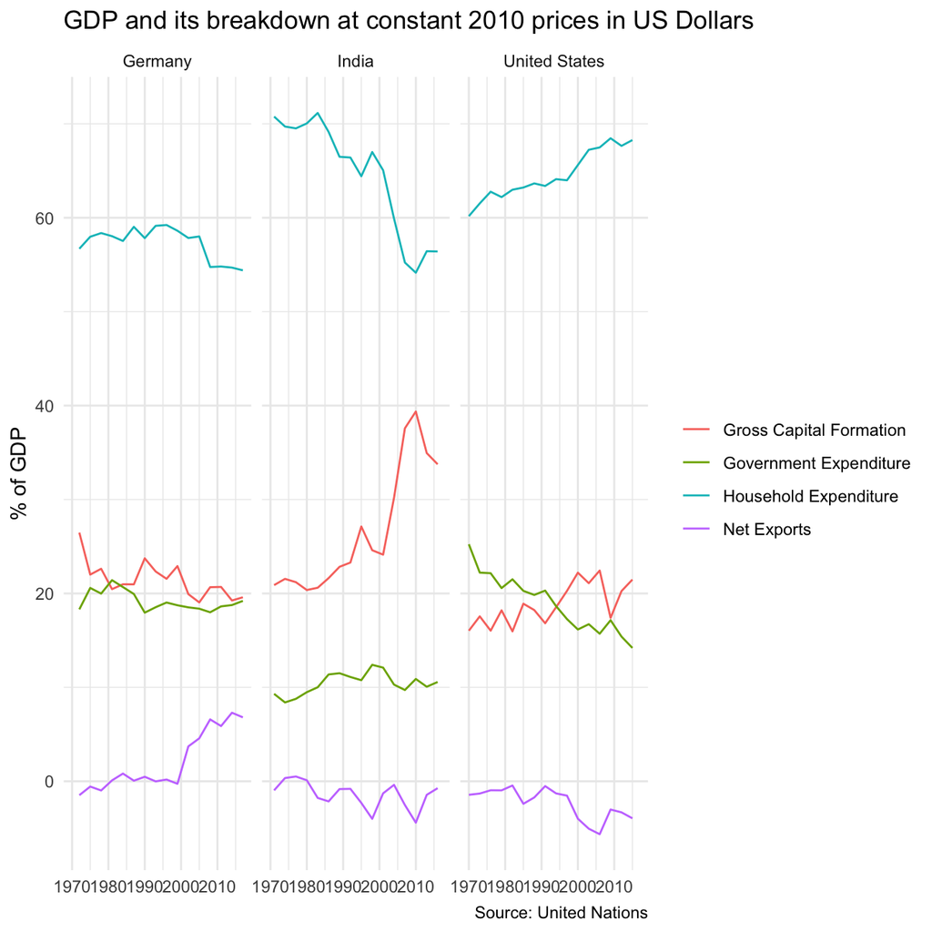

```r
wider_gdp %>%
  mutate(
    percentage_GE = 100*government_expenditure/gdp,
    percentage_GCF = 100*gross_capital_formation/gdp,
    percentage_HE = 100*household_expenditure/gdp,
    percentage_NE = 100*net_exports/gdp
  ) %>%
  select(country, year, percentage_GE, percentage_GCF, percentage_HE, percentage_NE) %>%
  pivot_longer(cols = 3:6, names_to = "component_of_gdp", values_to = "value") %>%
  ggplot(aes(x=year, y=value, color=component_of_gdp)) +
    geom_line() +
    facet_wrap(~country) +
    theme_minimal() +
    labs(
      title = "GDP and its breakdown at constant 2010 prices in US Dollars",
      x = NULL,
      y = "% of GDP",
      caption = "Source: United Nations",
      color = NULL
    ) +
    scale_color_hue(
      labels = c('Gross Capital Formation',
                 'Government Expenditure',
                 'Household Expenditure',
                 'Net Exports'
                 )
      )
```

> The graph clearly shows that Germany is an exporting country, whereas the US seems to import more than it exports, and India seems to fluctuate close to zero.

Finally, let’s plot a graph showing a dynamic of GDP and its components between Poland, Spain, Singapore and China over given time period.

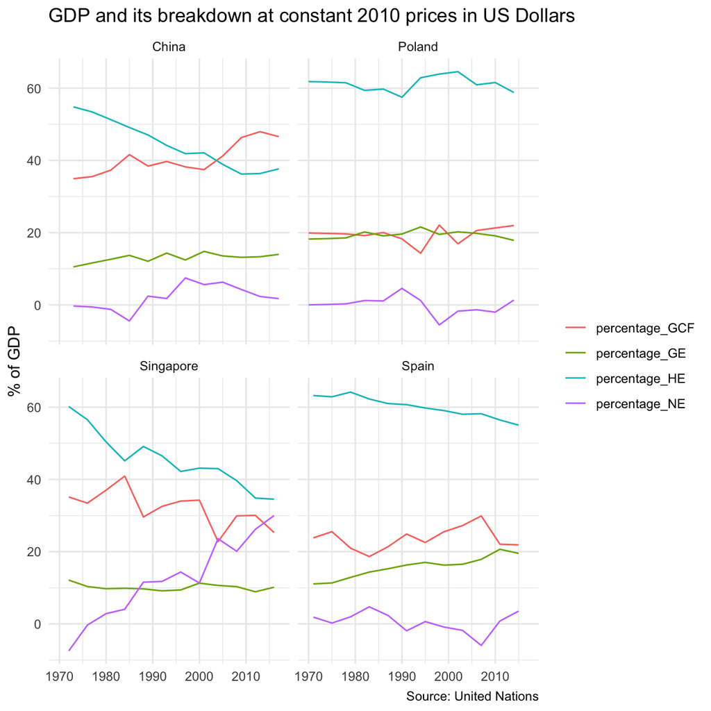

```r
country_list <- c("Poland","Spain", "Singapore", "China")

tidy_GDP_data <- UN_GDP_data %>%
  pivot_longer(cols=4:51,
               names_to = "Year",
               values_to = "value")

tidy_GDP_data<-tidy_GDP_data %>%
  filter(Country==country_list) %>%
  mutate(value=value/10^9)

tidy_GDP_for_graph1 <- tidy_GDP_data %>%
  mutate(components_of_GDP=case_when(
    grepl("Exports",IndicatorName) ~ "Exports",
    grepl("Gross capital formation",IndicatorName) ~ "Gross capital formation",
    grepl("Government",IndicatorName) ~ "Government expenditure",
    grepl("government",IndicatorName) ~ "Government expenditure",
    grepl("Household",IndicatorName) ~ "Household expenditure",
    grepl("household",IndicatorName) ~ "Household expenditure",
    grepl("Imports",IndicatorName)~"Imports"
  )) %>%
  mutate(Year = as.integer(Year)) %>%
  na.omit(components_of_GDP)

tidy_GDP_for_graph1 %>%
  select(Country, components_of_GDP, Year, value) %>%
  pivot_wider(names_from = components_of_GDP, values_from = value) %>%
  janitor::clean_names() %>%
  mutate(
    net_exports = exports - imports,
    gdp = household_expenditure + government_expenditure + gross_capital_formation + net_exports
    ) -> wider_gdp

wider_gdp %>%
  mutate(
    percentage_GE = 100*government_expenditure/gdp,
    percentage_GCF = 100*gross_capital_formation/gdp,
    percentage_HE = 100*household_expenditure/gdp,
    percentage_NE = 100*net_exports/gdp
  ) %>%
  select(country, year, percentage_GE, percentage_GCF, percentage_HE, percentage_NE) %>%
  pivot_longer(cols = 3:6, names_to = "component_of_gdp", values_to = "value") %>%
  ggplot(aes(x=year, y=value, color=component_of_gdp)) +
    geom_line() +
    facet_wrap(~country) +
    theme_minimal() +
    labs(
      title = "GDP and its breakdown at constant 2010 prices in US Dollars",
      x = NULL,
      y = "% of GDP",
      caption = "Source: United Nations",
      color = NULL
    ) +
    scale_fill_discrete(
      labels = c('Gross Capital Formation',
                 'Government Expenditure',
                 'Household Expenditure',
                 'Net Exports'
                 )
      )
```